# 206 HW 5

#### 3. Male and female salaries for starting postdoc and other positions (2015)

Does median salary differ significantly between male and female starting postdoc positions? Does median salary differ significantly between male and female PhD recipients in non-postdoc employment positions?

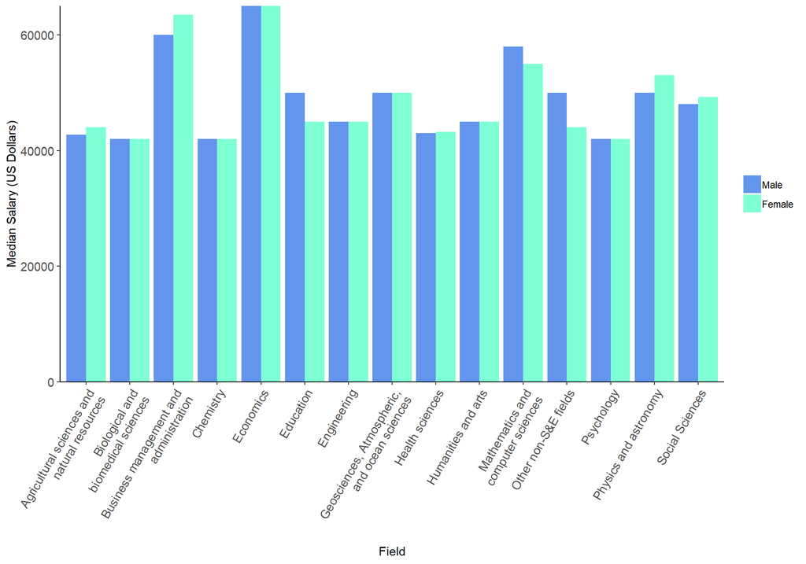

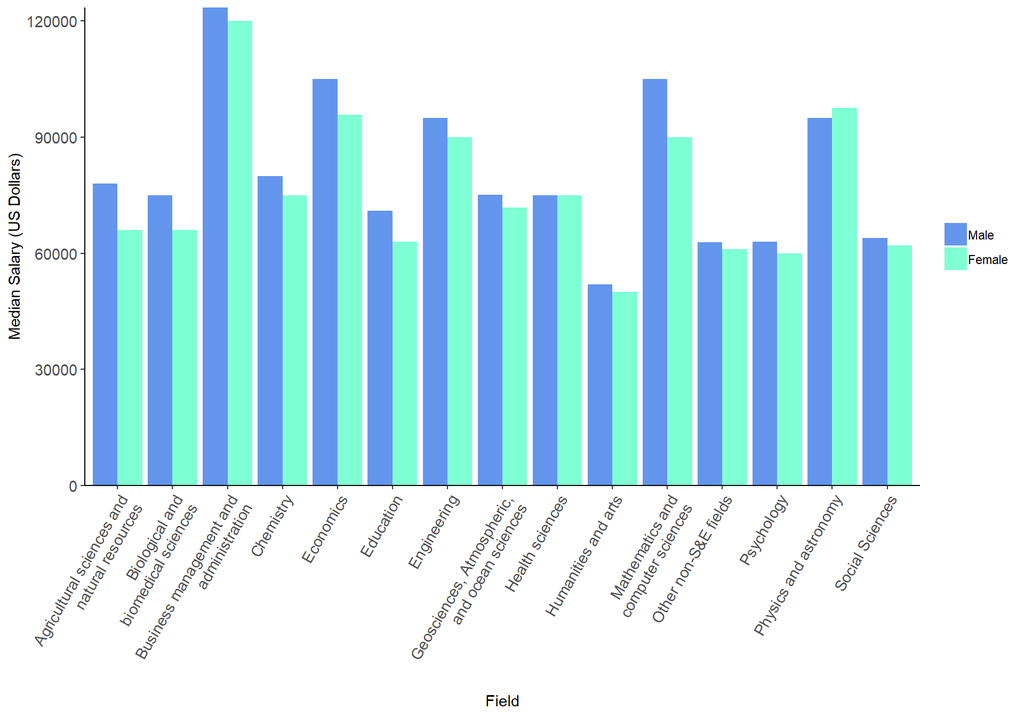

There was no significant difference in median salary for male and female starting postdoc positions (V = 19.5, p = 0.888, alpha = 0.05)

There was a significant difference in median salary for male and female starting in non-post-doc employment positions (V = 101, p = 0.003, alpha = 0.05)

#### 4. Exploring academic salaries for professors in U.S. colleges

|  | *Dependent variable:* |  |
| --- | --- | --- |
|  | Salary |  |
|  | (1) | (2) |
| DisciplineB | 15,626.350*** | 13,937.470*** |
|  | (2,730.403) | (2,346.534) |
| Faculty_RankAsstProf |  | -13,104.150*** |
|  |  | (4,167.315) |
| Faculty_RankProf |  | 32,928.400*** |
|  |  | (3,544.403) |
| Years_Since_Phd | 1,093.281*** | 61.011 |
|  | (106.845) | (127.010) |
| SexMale | 6,956.348 | 4,349.366 |
|  | (4,509.190) | (3,875.393) |
| Constant | 74,535.060*** | 80,988.470*** |
|  | (4,932.109) | (4,931.844) |
| Observations | 397 | 397 |
| R<sup>2</sup> | 0.245 | 0.447 |
| Adjusted R<sup>2</sup> | 0.239 | 0.440 |
| Residual Std. Error | 26,424.740 (df = 393) | 22,663.240 (df = 391) |
| F Statistic | 42.430*** (df = 3; 393) | 63.266*** (df = 5; 391) |
| *Note:* | p<0.1; p<0.05; p<0.01 |  |

```
                GVIF Df GVIF^(1/(2*Df))
```

Discipline 1.055727 1 1.027486 Faculty_Rank 1.987205 2 1.187301 Years_Since_Phd 2.065517 1 1.437191 Sex 1.028359 1 1.014080 [1] 9097.22 Discipline Years_Since_Phd Sex 1.051414 1.075202 1.024078 [1] 9217.169